# Multi-Environment Trials and Genotype-by-Environment Models

mixedFlowR tutorial series

# 1 Purpose

Multi-environment trials (METs) evaluate genotypes across environments, years, locations, or management conditions. The central statistical problem is not simply whether environments differ; it is how genotype performance changes across environments and how information should be borrowed across the resulting covariance structure.

`mixedFlowR` delegates MET and GxE estimation to `sommer`, a mixed-model solver designed for complex covariance and quantitative-genetic applications (Covarrubias-Pazaran 2016).

# 2 1. Learning objectives

You will learn to:

- audit genotype-by-environment replication;
- fit a baseline MET model;
- distinguish environment fixed effects from genotype random effects;
- fit diagonal, unstructured, and reduced-rank factor-analytic GxE covariance structures;
- understand covariance borrowing across environments;
- recognize overparameterization in unstructured GxE;
- interpret reduced-rank GxE cautiously;
- report MET results beyond a single overall genotype mean.

# 3 2. Teaching dataset

```r
library(mixedFlowR)
m <- mixed_data("met")
head(m)
```

```
#>   environment rep genotype    yield
#> 1          E1  R1      G01 44.74466
#> 2          E1  R1      G02 45.48518
#> 3          E1  R1      G03 43.67146
#> 4          E1  R1      G04 40.75467
#> 5          E1  R1      G05 34.41193
#> 6          E1  R1      G06 49.69628
```

Inspect replication.

```r
with(m, table(environment, rep))
```

```
#>            rep
#> environment R1 R2 R3
#>          E1 10 10 10
#>          E2 10 10 10
#>          E3 10 10 10
#>          E4 10 10 10
```

```r
with(m, table(environment, genotype))
```

```
#>            genotype
#> environment G01 G02 G03 G04 G05 G06 G07 G08 G09 G10
#>          E1   3   3   3   3   3   3   3   3   3   3
#>          E2   3   3   3   3   3   3   3   3   3   3
#>          E3   3   3   3   3   3   3   3   3   3   3
#>          E4   3   3   3   3   3   3   3   3   3   3
```

Observed environment means:

```r
aggregate(yield ~ environment, m, mean)
```

```
#>   environment    yield
#> 1          E1 43.71614
#> 2          E2 49.04087
#> 3          E3 53.25916
#> 4          E4 56.02361
```

Observed genotype means:

```r
gm <- aggregate(yield ~ genotype, m, mean)
gm[order(-gm$yield), ][1:8, ]
```

```
#>    genotype    yield
#> 8       G08 57.99054
#> 6       G06 52.13317
#> 2       G02 51.38021
#> 7       G07 51.15748
#> 3       G03 50.99575
#> 9       G09 50.32333
#> 1       G01 49.70605
#> 10      G10 49.14716
```

These raw means ignore GxE covariance and should not be treated as complete MET inference.

# 4 3. Visualize genotype profiles

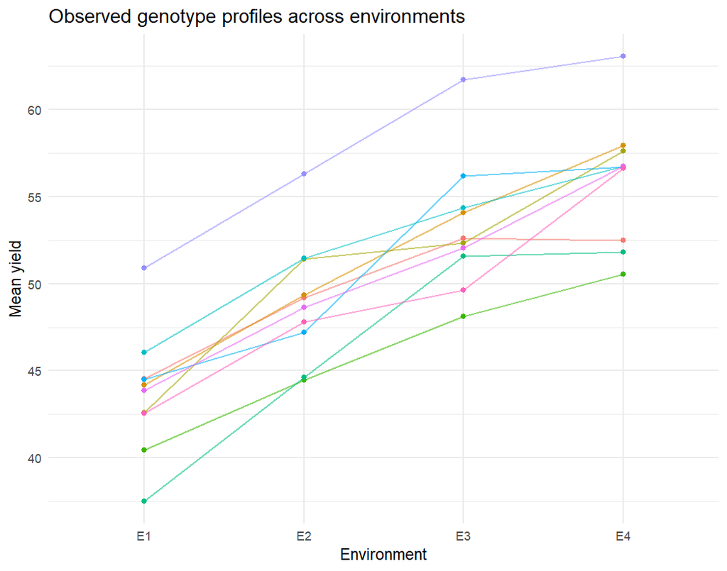

```r
if (requireNamespace("ggplot2", quietly = TRUE)) {
  prof <- aggregate(yield ~ genotype + environment, m, mean)

  ggplot2::ggplot(
    prof,
    ggplot2::aes(environment, yield, group = genotype, colour = genotype)
  ) +
    ggplot2::geom_line(alpha = 0.55) +
    ggplot2::geom_point(size = 1.5) +
    ggplot2::labs(
      x = "Environment",
      y = "Mean yield",
      colour = "Genotype",
      title = "Observed genotype profiles across environments"
    ) +
    ggplot2::theme_minimal(base_size = 11) +
    ggplot2::theme(legend.position = "none")
}
```

Crossing profiles are a descriptive sign of interaction but do not quantify the covariance structure.

# 5 4. Baseline MET model

Treat environment as fixed and genotype as random.

```r
if (requireNamespace("sommer", quietly = TRUE)) {
  met_fit <- mixed_met(
    fixed  = yield ~ environment,
    random = ~ genotype,
    data   = m,
    solver = "mmes"
  )

  met_fit
}
```

```
#> iteration    LogLik     wall    cpu(sec)   restrained
#>     1      9.97022   23:54:44      0           0
#>     2      16.2751   23:54:44      0           0
#>     3      17.0214   23:54:44      0           0
#>     4      17.067   23:54:44      0           0
#>     5      17.0674   23:54:44      0           0
#>     6      17.0674   23:54:44      0           0
#> $call
#> mixed_met(fixed = yield ~ environment, random = ~genotype, data = m,
#>     solver = "mmes")
#>
#> $engine
#> [1] "sommer"
#>
#> $model
```

[output cut: 937 more lines]

The inferential target here is the environment mean structure plus a population-level genotype variance component.

# 6 5. Alternative random environment baseline

```r
if (requireNamespace("sommer", quietly = TRUE)) {
  met_random_env <- mixed_met(
    fixed  = yield ~ 1,
    random = ~ genotype + environment,
    data   = m
  )
}
```

```
#> iteration    LogLik     wall    cpu(sec)   restrained
#>     1      -5.88527   23:54:45      0           0
#>     2      9.34373   23:54:45      0           0
#>     3      10.8692   23:54:45      0           0
#>     4      10.9558   23:54:45      0           0
#>     5      10.9565   23:54:45      0           0
#>     6      10.9565   23:54:45      0           0
```

Whether environment is fixed or random depends on the target population and sampling interpretation. Do not choose based only on coding convenience.

# 7 6. Diagonal GxE covariance

A diagonal structure allows environment-specific GxE variances but no GxE covariance across environments.

```r
if (requireNamespace("sommer", quietly = TRUE)) {
  gxe_diag <- mixed_gxe(
    data        = m,
    response    = "yield",
    genotype    = "genotype",
    environment = "environment",
    model       = "diagonal"
  )

  gxe_diag
}
```

```
#> iteration    LogLik     wall    cpu(sec)   restrained
#>     1      -6.15212   23:54:45      0           0
#>     2      -1.57433   23:54:45      0           0
#>     3      -0.371112   23:54:45      0           0
#>     4      -0.267636   23:54:45      0           0
#>     5      -0.266657   23:54:45      0           0
#>     6      -0.266647   23:54:45      0           0
#> $call
#> mixed_gxe(data = m, response = "yield", genotype = "genotype",
#>     environment = "environment", model = "diagonal")
#>
#> $engine
#> [1] "sommer"
#>
#> $model
```

[output cut: 1431 more lines]

# 8 7. Unstructured GxE covariance

```r
if (requireNamespace("sommer", quietly = TRUE)) {
  gxe_us <- mixed_gxe(
    m,
    response = "yield",
    genotype = "genotype",
    environment = "environment",
    model = "unstructured"
  )
}
```

```
#> iteration    LogLik     wall    cpu(sec)   restrained
#>     1      6.37724   23:54:45      0           0
#>     2      16.5328   23:54:45      0           0
#>     3      18.5728   23:54:45      0           0
#>     4      18.8439   23:54:45      0           0
#>     5      18.8474   23:54:45      0           0
#>     6      18.8474   23:54:45      0           0
```

An unstructured covariance estimates many environment-specific variances and covariances. Parameter count grows quickly with the number of environments.

# 9 8. Reduced-rank factor-analytic GxE

```r
if (requireNamespace("sommer", quietly = TRUE)) {
  gxe_fa2 <- mixed_gxe(
    data        = m,
    response    = "yield",
    genotype    = "genotype",
    environment = "environment",
    model       = "fa",
    nPC         = 2
  )
}
```

```
#> iteration    LogLik     wall    cpu(sec)   restrained
#>     1      10.0214   23:54:45      0           1
#>     2      15.8998   23:54:45      0           1
#>     3      16.6287   23:54:45      0           1
#>     4      16.6796   23:54:45      0           1
#>     5      16.6812   23:54:45      0           1
#>     6      16.6814   23:54:45      0           1
#>     7      16.6814   23:54:45      0           1
```

Reduced-rank models summarize major covariance dimensions and can be more parsimonious than a full unstructured matrix.

# 10 9. One-factor reduced-rank sensitivity

```r
if (requireNamespace("sommer", quietly = TRUE)) {
  gxe_fa1 <- mixed_gxe(
    m,
    "yield",
    "genotype",
    "environment",
    model = "fa",
    nPC = 1
  )
}
```

```
#> iteration    LogLik     wall    cpu(sec)   restrained
#>     1      7.62071   23:54:45      0           0
#>     2      15.5836   23:54:45      0           0
#>     3      16.4697   23:54:45      0           0
#>     4      16.5218   23:54:45      0           0
#>     5      16.5223   23:54:45      0           0
#>     6      16.5223   23:54:45      0           0
```

Compare one and two retained factors through likelihood descriptors and, importantly, interpretability and convergence.

# 11 10. What factor-analytic structure means

A factor-analytic covariance represents GxE through a smaller set of latent covariance dimensions.

Conceptually:

- environments have loadings on latent factors;
- genotypes have factor scores;
- the product helps reconstruct covariance in performance;
- residual environment-specific GxE variance can remain.

Do not automatically interpret a latent factor as rainfall, temperature, or soil fertility unless external environmental covariates support that interpretation.

# 12 11. Stability is multidimensional

A genotype can have:

- high overall mean and high interaction;
- moderate mean and stable response;
- specific adaptation to one environment class;
- crossover interaction with other genotypes.

A single stability score can hide these distinctions.

# 13 12. Crossed random-effects baseline

For teaching, a simpler `lme4` crossed model can illustrate genotype and environment heterogeneity.

```r
if (requireNamespace("lme4", quietly = TRUE)) {
  crossed <- mixed_crossed(
    data = m,
    response = "yield",
    fixed = "1",
    groups = c("genotype", "environment")
  )
}
```

This is not a substitute for a full GxE covariance model because it lacks environment-specific genotype covariance structure.

# 14 13. Compare covariance complexity conceptually

| Structure | Strength | Limitation |
| --- | --- | --- |
| diagonal | few covariance assumptions | no cross-environment covariance |
| unstructured | maximally flexible covariance | many parameters, may be unstable |
| FA / reduced rank | parsimonious covariance | latent factors require cautious interpretation |

# 15 14. Missing cells and unbalanced METs

Mixed models can accommodate incomplete genotype-by-environment tables under their likelihood assumptions, but information borrowing becomes uneven.

Always inspect support.

```r
mixed_balance(m, c("environment", "rep", "genotype"))
```

```
#>     environment rep genotype n
#> 1            E1  R1      G01 1
#> 2            E2  R1      G01 1
#> 3            E3  R1      G01 1
#> 4            E4  R1      G01 1
#> 5            E1  R2      G01 1
#> 6            E2  R2      G01 1
#> 7            E3  R2      G01 1
#> 8            E4  R2      G01 1
#> 9            E1  R3      G01 1
#> 10           E2  R3      G01 1
#> 11           E3  R3      G01 1
#> 12           E4  R3      G01 1
#> 13           E1  R1      G02 1
#> 14           E2  R1      G02 1
```

[output cut: 106 more lines]

Create a missing-cell teaching scenario.

```r
m_missing <- m[-1, ]
mixed_balance(m_missing, c("environment", "rep", "genotype"))
```

```
#>     environment rep genotype n
#> 1            E2  R1      G01 1
#> 2            E3  R1      G01 1
#> 3            E4  R1      G01 1
#> 4            E1  R2      G01 1
#> 5            E2  R2      G01 1
#> 6            E3  R2      G01 1
#> 7            E4  R2      G01 1
#> 8            E1  R3      G01 1
#> 9            E2  R3      G01 1
#> 10           E3  R3      G01 1
#> 11           E4  R3      G01 1
#> 12           E1  R1      G02 1
#> 13           E2  R1      G02 1
#> 14           E3  R1      G02 1
```

[output cut: 106 more lines]

# 16 15. Prediction and ranking caution

BLUP-like genotype predictions are conditional on:

- fitted covariance structure;
- environment representation;
- residual model;
- genotype fixed/random assumption;
- relationship matrices if supplied in more advanced `sommer` models.

Do not report ranks without uncertainty or stability context.

# 17 16. Extending to pedigree/genomic covariance

The `mixed_met()` wrapper can pass advanced `sommer` random-effect structures through `...`. Such models should be documented carefully because known relationship matrices change the interpretation of genotype covariance.

A generic template is shown but not evaluated:

```r
# Define `genomic_random_formula` from a scientifically justified
# sommer relationship structure before fitting.
fit_genomic <- mixed_met(
  fixed = yield ~ environment,
  random = genomic_random_formula,
  data = met_with_relationships,
  solver = "mmes"
)
```

# 18 17. Reporting checklist

Report:

- environments and their sampling interpretation;
- replication within environments;
- genotype fixed/random status;
- residual covariance assumption;
- GxE covariance structure;
- number of factors in reduced-rank models;
- convergence diagnostics;
- genotype predictions and uncertainty;
- evidence of crossover or specific adaptation;
- environmental covariates used to interpret latent factors, if any.

# 19 18. Exercises

1. Fit diagonal and unstructured GxE models and compare parameter complexity.
2. Fit FA1 and FA2 and explain what additional latent dimension is being allowed.
3. Remove several genotype-environment cells and inspect support before refitting.
4. Plot raw genotype profiles and identify examples of crossover interaction.

# 20 19. Key take-home messages

- MET analysis is primarily about genotype performance **across** environments, not environment means alone.
- GxE covariance structure determines how information is borrowed across environments.
- Unstructured covariance can become parameter-heavy quickly.
- Factor-analytic factors are statistical dimensions until externally interpreted.
- Ranking genotypes without uncertainty and interaction context is incomplete.

# 21 20. Next vignette

Continue with `15-publication-output.Rmd` for publication-ready figures, tables, exports, and report generation.

# 22 References

The MET/GxE implementation is built on `sommer` and its mixed-model covariance framework (Covarrubias-Pazaran 2016).

Covarrubias-Pazaran, Giovanny. 2016. “Genome-Assisted Prediction of Quantitative Traits Using the r Package Sommer.” *PLOS ONE* 11 (6): e0156744. https://doi.org/10.1371/journal.pone.0156744.